# lab10-Evaluation

```python
from textblob import TextBlob, Word
import nltk
from collections import Counter
import matplotlib.pyplot as plt
import seaborn as sns
import re
nltk.download('punkt')
nltk.download('stopwords') # For removing common words
nltk.download('averaged_perceptron_tagger') # For Part-of-Speech tagging (used in lemmatization)
nltk.download('wordnet') # For lemmatization
#! python3 -m textblob.download_corpora
# Sample reviews with associated sentiment (as provided)
```

```
True
```

```python
import pandas as pd
df = pd.read_csv("datasets/amazon_review.csv")
df
```

|  | reviewText | Positive |
| --- | --- | --- |
| 0 | This is a one of the best apps acording to a b... | 1 |
| 1 | This is a pretty good version of the game for ... | 1 |
| 2 | this is a really cool game. there are a bunch ... | 1 |
| 3 | This is a silly game and can be frustrating, b... | 1 |
| 4 | This is a terrific game on any pad. Hrs of fun... | 1 |
| ... | ... | ... |
| 19995 | this app is fricken stupid.it froze on the kin... | 0 |
| 19996 | Please add me!!!!! I need neighbors! Ginger101... | 1 |
| 19997 | love it! this game. is awesome. wish it had m... | 1 |
| 19998 | I love love love this app on my side of fashio... | 1 |
| 19999 | This game is a rip off. Here is a list of thin... | 0 |

20000 rows × 2 columns

1. Can you perform a sentiment analysis on the collection of product reviews, classify each one as 'positive', 'negative', or 'neutral', and then generate a bar chart to visualize the distribution of these sentiments?"
2. convert the text to lowercase, remove punctuation and numbers, filter out common stopwords, and then lemmatize the remaining words using their appropriate part-of-speech tags.
3. fter the text has been fully preprocessed and lemmatized, could you calculate the frequency of each unique word and then display a bar graph showing the top 15 most common words?
4. generate a word cloud based on the entire corpus of lemmatized review words to provide a visual summary of the most prominent terms.
5. Visualize the frequency of nouns, verbs, adjectives in this text.

## 1. Can you perform a sentiment analysis on the collection of product reviews, classify each one as 'positive', 'negative', or 'neutral', and then generate a bar chart to visualize the distribution of these sentiments?

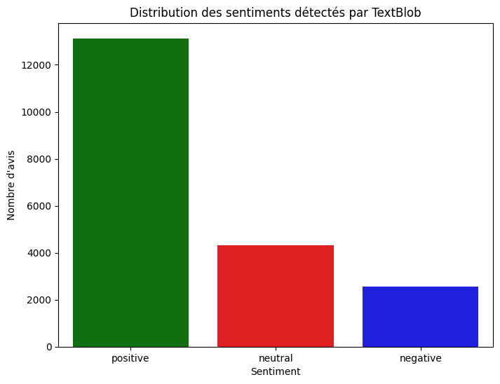

```python
# Chargement du dataset
df = pd.read_csv("datasets/amazon_review.csv")

# Nettoyage, minuscule et suppression ponctuation, chiffres, stopwords
stop_words = set(nltk.corpus.stopwords.words('english'))

def preprocess_text(text):
    text = text.lower()
    text = re.sub(r'[^\w\s]', '', text)  # supprime ponctuation
    text = re.sub(r'\d+', '', text)      # supprime chiffres
    return text

df['clean_text'] = df['reviewText'].apply(preprocess_text)

# Fonction pour convertir tag Treebank -> WordNet (pour lemmatization)
def get_wordnet_pos(treebank_tag):
    if treebank_tag.startswith('J'):
        return 'a'  # adjectif
    elif treebank_tag.startswith('V'):
        return 'v'  # verbe
    elif treebank_tag.startswith('N'):
        return 'n'  # nom
    elif treebank_tag.startswith('R'):
        return 'r'  # adverbe
    else:
        return 'n'  # défaut: nom

# Lemmatisation avec POS tagging + filtrage stopwords
def lemmatize_text(text):
    blob = TextBlob(text)
    lemmas = []
    for word, tag in blob.tags:
        if word in stop_words or len(word) < 2:
            continue
        pos = get_wordnet_pos(tag)
        lemma = Word(word).lemmatize(pos)
        lemmas.append(lemma)
    return lemmas

df['lemmas'] = df['clean_text'].apply(lemmatize_text)

# --- Sentiment Analysis avec TextBlob ---
def get_sentiment(text):
    blob = TextBlob(text)
    polarity = blob.sentiment.polarity
    if polarity > 0.1:
        return 'positive'
    elif polarity < -0.1:
        return 'negative'
    else:
        return 'neutral'

df['textblob_sentiment'] = df['reviewText'].apply(get_sentiment)

# Visualisation de la distribution des sentiments
sentiment_counts = df['textblob_sentiment'].value_counts()

plt.figure(figsize=(8,6))
sns.barplot(x=sentiment_counts.index, y=sentiment_counts.values, palette=['green','red','blue'])
plt.title('Distribution des sentiments détectés par TextBlob')
plt.xlabel('Sentiment')
plt.ylabel('Nombre d\'avis')
plt.show()
```

## 2. Convert the text to lowercase, remove punctuation and numbers, filter out common stopwords, and then lemmatize the remaining words using their appropriate part-of-speech tags.

```python
def lemmatize_text(text):
    blob = TextBlob(text)
    lemmas = []
    for word, tag in blob.tags:
        if word in stop_words or len(word) < 2:
            continue
        pos = get_wordnet_pos(tag)
        lemma = Word(word).lemmatize(pos)
        lemmas.append(lemma)
    return lemmas

df['lemmas'] = df['clean_text'].apply(lemmatize_text)
```

## 3. After the text has been fully preprocessed and lemmatized, could you calculate the frequency of each unique word and then display a bar graph showing the top 15 most common words

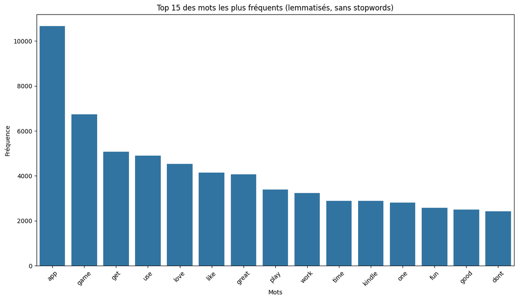

```python
all_lemmas = [lemma for sublist in df['lemmas'] for lemma in sublist]
word_counts = Counter(all_lemmas)

top_15 = word_counts.most_common(15)
words, counts = zip(*top_15)

plt.figure(figsize=(12,7))
sns.barplot(x=list(words), y=list(counts))
plt.title("Top 15 des mots les plus fréquents (lemmatisés, sans stopwords)")
plt.xlabel("Mots")
plt.ylabel("Fréquence")
plt.xticks(rotation=45)
plt.tight_layout()
plt.show()
```

## 4. Generate a word cloud based on the entire corpus of lemmatized review words to provide a visual summary of the most prominent terms.

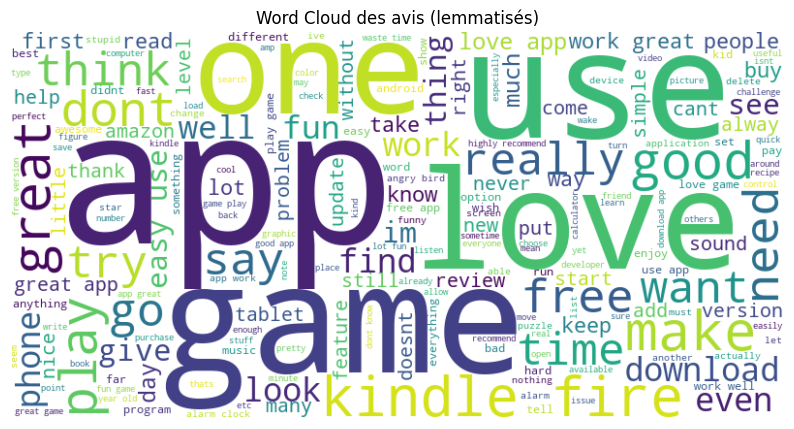

```python
full_text = ' '.join(all_lemmas)
wordcloud = WordCloud(width=800, height=400, background_color='white').generate(full_text)

plt.figure(figsize=(10,8))
plt.imshow(wordcloud, interpolation='bilinear')
plt.axis('off')
plt.title("Word Cloud des avis (lemmatisés)")
plt.show()
```

## 5. Visualize the frequency of nouns, verbs, adjectives in this text.

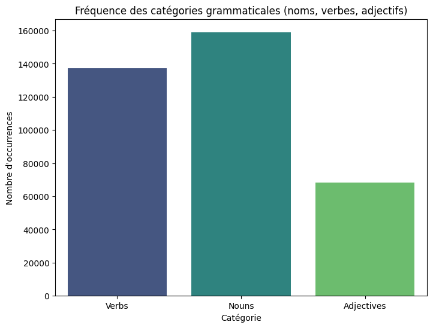

```python
pos_counter = Counter()

for text in df['clean_text']:
    blob = TextBlob(text)
    for _, tag in blob.tags:
        if tag.startswith('N'):
            pos_counter['Nouns'] += 1
        elif tag.startswith('V'):
            pos_counter['Verbs'] += 1
        elif tag.startswith('J'):
            pos_counter['Adjectives'] += 1

plt.figure(figsize=(8,6))
sns.barplot(x=list(pos_counter.keys()), y=list(pos_counter.values()), palette='viridis')
plt.title("Fréquence des catégories grammaticales (noms, verbes, adjectifs)")
plt.xlabel("Catégorie")
plt.ylabel("Nombre d'occurrences")
plt.show()
```